# Laboratorio Simulación - Procesos

Jorge de la Vega

24 de septiembre de 2018

# Ejemplos de simulación de Procesos Estocásticos

## Cadena de Markov

### Cadenas de Markov finitas

Solución:

```r
N <- 100 #Numero de trayectorias
tiempo <- 1000 #longitud de las trayectorias
P <- matrix(c(1/3,0,0,1/3,2/3,1/2,1/3,1/3,1/2),nrow=3)
X0 <- sample(1:3, N, prob=c(0.5,0.5,0), rep=T) #vector de estados iniciales para las 10 trayectorias

simulaciones <- c()  # guarda las taryectorias del proceso
X <- c()             # proceso
for(i in 1:N){
  X[1] <- X0[i]
  for(j in 2:(tiempo+1))X[j] <- sample(1:3, 1, prob =P[X[j-1], ])
    simulaciones <- cbind(simulaciones,X)
}

#para 1:
X100 <- simulaciones[tiempo+1,]
table(X100)/sum(table(X100))
```

```
## X100
##    2    3
## 0.57 0.43
```

```r
#para 2:
X1_100 <- simulaciones[(tiempo-100):tiempo, c(1,10,100)]
apply(X1_100,2,function(x)table(x)/sum(table(x)))
```

```
##           X         X         X
## 2 0.5841584 0.6138614 0.4851485
## 3 0.4158416 0.3861386 0.5148515
```

### Caminatas aleatorias simples en los enteros.

Los elementos de la matriz de transición están dados por la siguiente ecuación:

$$P_{i,j} = \begin{cases} p_i & j=i+1 \\ q_i & j=i-1 \\ 0 & j\neq i\pm 1\end{cases}, p_i+q_i=1$$
La caminata puede recorrer todos los enteros, y en caso de ser acotada, debe haber condiciones de frontera, como reflecciones o absorsión.

Se requiere un valor inicial para la variable aleatoria, digamos $X_0$, y sea $S_0=X_0$ y $S_k=\sum_{i=0}^k X_k = S_{k-1}+X_k$ El algoritmo es el siguiente para $i=1,2,\ldots$:

1. Genera $p_i \sim U(0,1)$ y define $q_i=1-p_i$.
2. Calcula $X_i \sim Ber(\{1,-1\},p_i)$
3. Calcula $S_i=S_{i-1} +X_k$

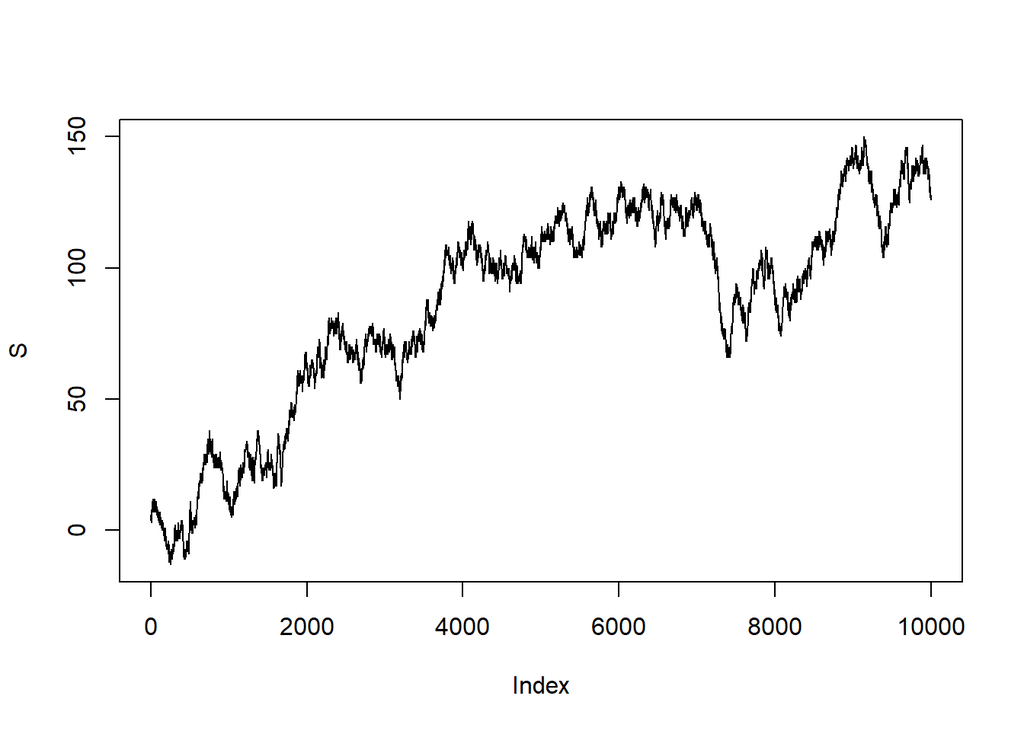

```r
tiempo <- 10000  #longitud de la cadena
S <- X<- 5 #algún valor inicial
for(i in 2:tiempo){
  p <- runif(1)
  X[i] <- sample(c(1,-1),1,prob=c(p,1-p))
  S[i] <- S[i-1] + X[i]
}
plot(S,type="l")
```

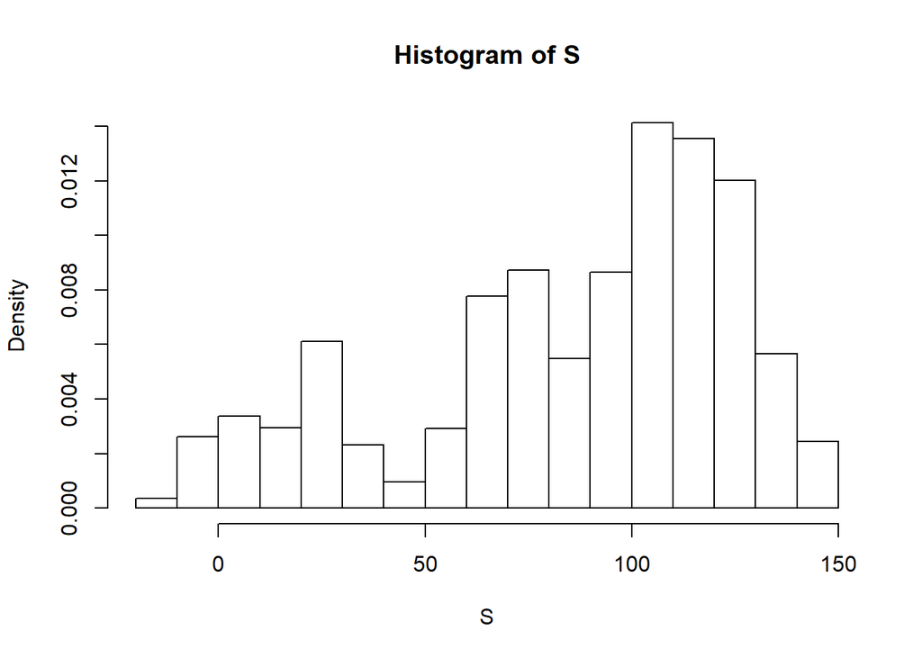

```r
hist(S,breaks=20,prob=T)
```

1. Â¿Cuál es el tiempo promedio que se tarda en regresar al 0 una vez que se está en él?

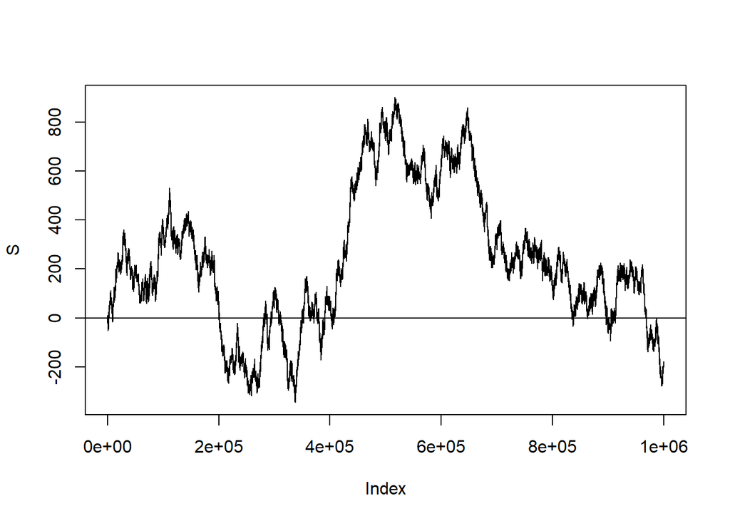

```r
tiempo <- 1000000
X0 <- 0
X <- sample(c(-1,1),size=tiempo,rep=T)
S <- cumsum(c(X0,X))
plot(S,type="l")
abline(h=0)
```

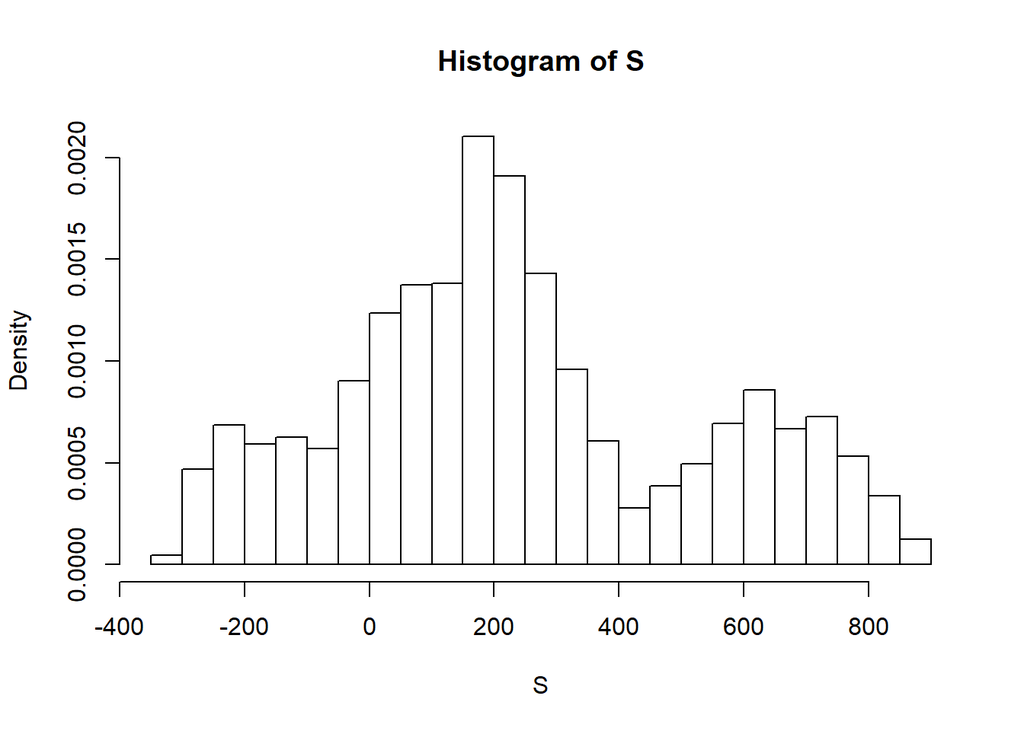

```r
hist(S,breaks=20,prob=T)
```

### Caminata aleatoria general

Los elementos de la matriz de transición están dados por la siguiente ecuación:

$$P_{i,j} = \begin{cases} p_i & j=i+1 \\ r_i & j=i \\ q_i & j=i-1 \\ 0 & j\notin \{i-1,i,i+1\} \end{cases}, p_i+r_i+q_i=1$$

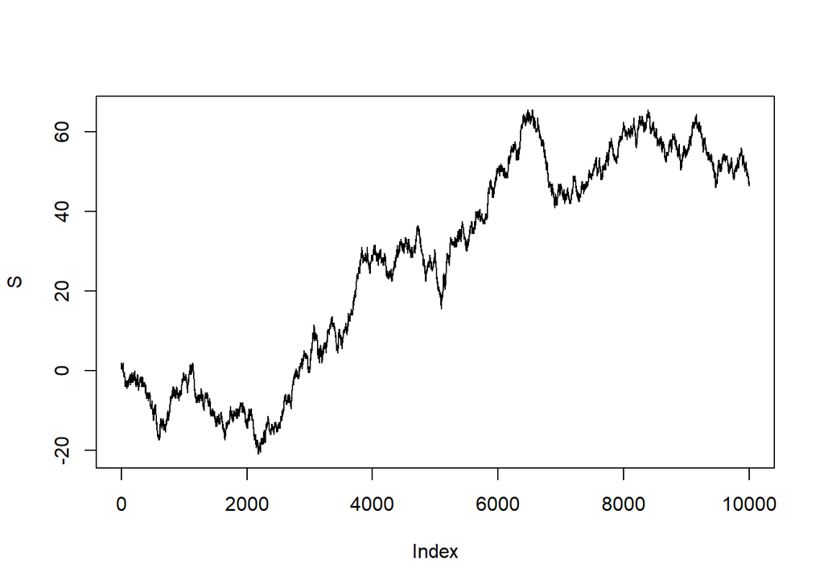

```r
tiempo <- 10000  #longitud de la cadena
S <- X <- sample(-10:10,1)  #algún valor inicial
for(i in 2:tiempo){
  a <- runif(3)
  p <- a/sum(a)  #normaliza el vector de probabilidades
  X[i] <- sample(c(1/2,0,-1/2),1,prob=p)
  S[i] <- S[i-1] + X[i]
}
plot(S,type="l")
```

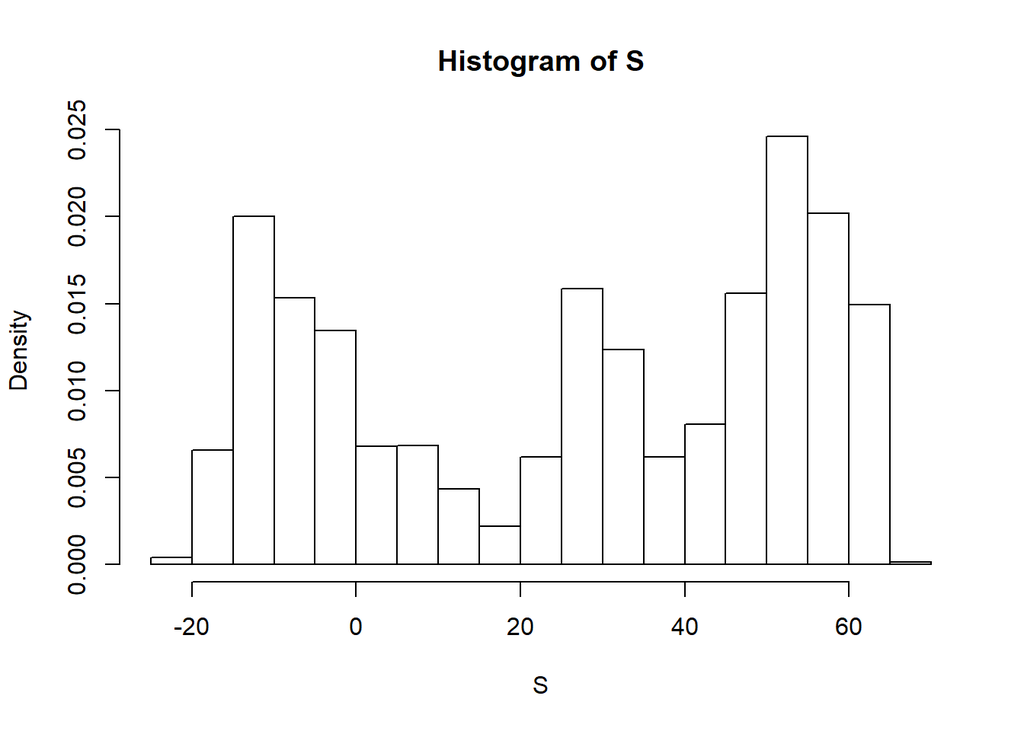

```r
hist(S,breaks=20,prob=T)
```

## Proceso de Wiener

### Proceso Browniano simple

Ejercicio: Simular un proceso browniano (o de Wiener) en el intervalo $t\in [0,1]$ con $n=1000$ puntos. En este ejercicio podemos notar el comportamiento fractal del proceso Browniano si cambiamos el valor de $t$ a valores más chicos o más grandes.

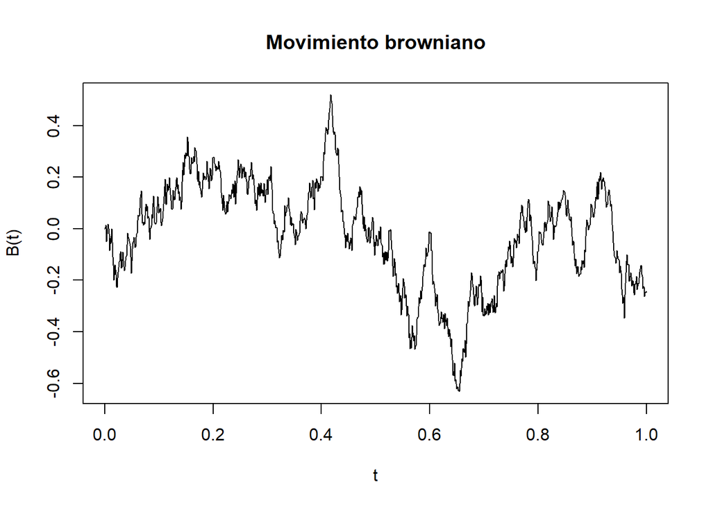

```r
n <- 1000 #partición
tiempo <- 1  #simulación en el intervalo [0,tiempo] = [0,1]
delta <- tiempo/n #incrementos de la partición del intervalo
B <- cumsum(c(0, rnorm(n, 0, sqrt(delta)))) #usando la versión acumulativa
a <- seq(0, tiempo, by=delta) # puntos de la partición del intervalo [0,tiempo]
plot(a, B, type="l",main="Movimiento browniano",xlab="t", ylab="B(t)")
```

2. Escribir una función que genere el proceso de Wiener con la opción de guardar N trayectorias, y que incluya cuantiles del 95% aproximados de la distribución normal de $B(t)$ para $t\in(0,1)$

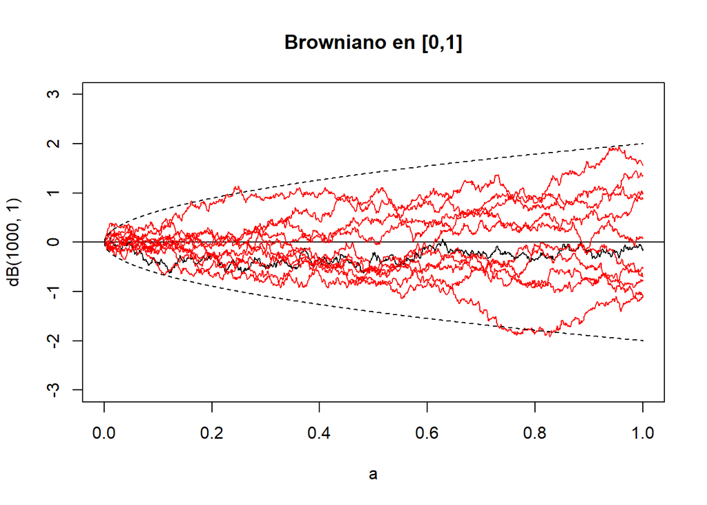

```r
dB <- function(n, TT){
  #Esta función genera un proceso de Wiener con n observaciones
  dt <- TT/n  # incremento del intervalo para obtener n puntos.
  return(cumsum(c(0, rnorm(n, 0, sqrt(dt)))))
}

plot(a, dB(1000,1), type = "l", main = "Browniano en [0,1]", ylim = c(-3,3))
abline(h=0)
for(i in 1:10) lines(a, dB(1000,1), col = "red") #simula 10 trayectorias
lines(a, -2*sqrt((0:1000)/1000), lty = 2)
lines(a,  2*sqrt((0:1000)/1000), lty = 2)
```

3. Generar un proceso Browniano en el espacio, considerando cada uno de sus componentes como un proceso Browniano simple. Este ejemplo se refiere típicamente como “el andar del borracho”

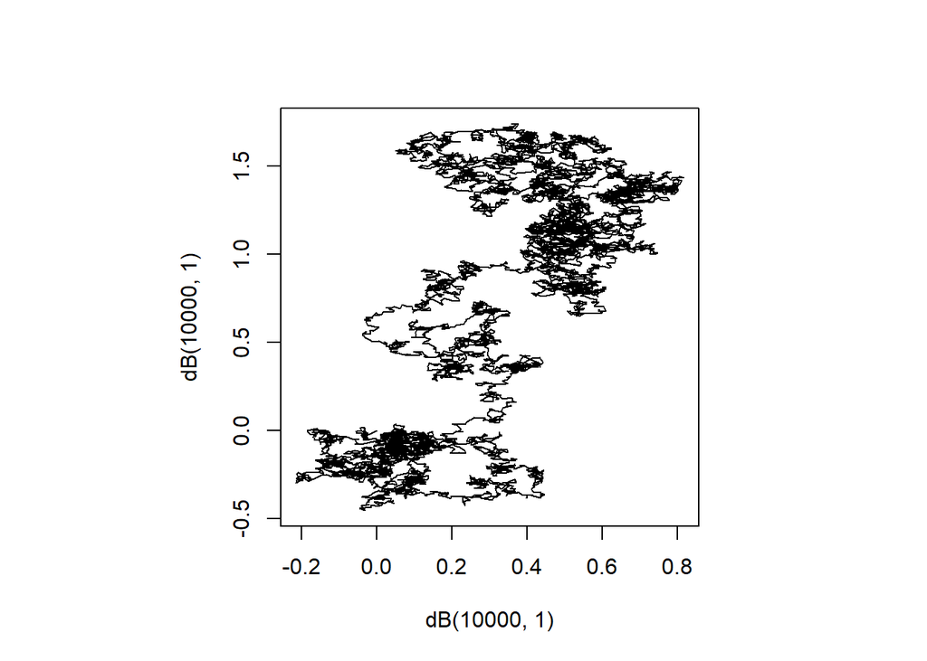

```r
par(pty="s")
plot(dB(10000,1), dB(10000,1), type = "l")
```

### Simulación de un proceso generalizado de Wiener

El proceso generalizado de Wiener agrega una tendencia al proceso simple de Wiener. Por ejemplo, si $a=2$, $b=0.5$,

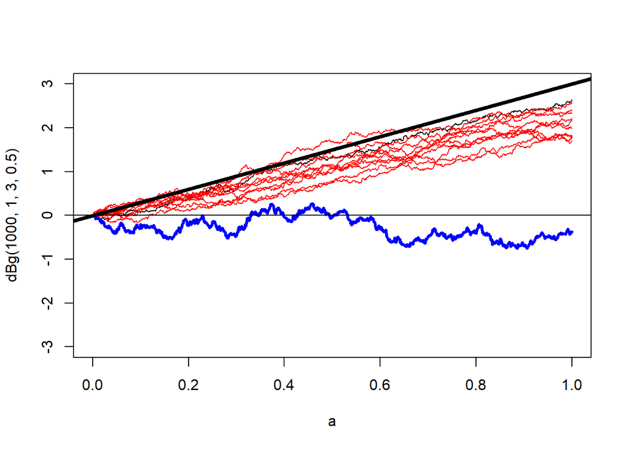

```r
dBg <- function(n,TT,a,b){
  #Función para un proceso Browniano Geométrico
  dt <- TT/n  # incremento del intervalo para cubrir [0,TT] en n puntos
  dB <- c(0,cumsum(rnorm(n,0,sqrt(dt))))
  dBG <- a*cumsum(rep(TT/n,n+1)) + b*dB
}

plot(a,dBg(1000,1,3,0.5),type="l",ylim=c(-3,3))
for(i in 1:10) lines(a,dBg(1000,1,2,0.5),col="red") #simula 10 trayectorias.
lines(a,dB(1000,1),col="blue",lwd=3)
abline(a = 0,b = 3,lwd=4)
abline(h=0)
```

### Simulación de un proceso de Wiener Geométrico

El caso del movimiento Browniano geométrico es que corresponde al precio de un instrumento financiero.

Si $S_t$ denota el precio del instrumento en el tiempo $t$, entonces
$$S_t = S_{t-1}e^{(\mu-\sigma^2/2)dt+b\sqrt{dt}\epsilon}$$
Donde $\mu$ denota el rendimiento instantáneo del instrumento financiero y $\sigma^2$ denota la volatilidad en la unidad de tiempo.

Esta ecuación se deriva de considerar que el rendimiento del instrumento se puede espresar en función del precio como
$$\frac{dS_t}{S_t} = \mu dt + \sigma dB$$
y para resolver la ecuación usamos la transformación $G=\log S_t$ y aplicamos las fórmulas de ItÃ´.

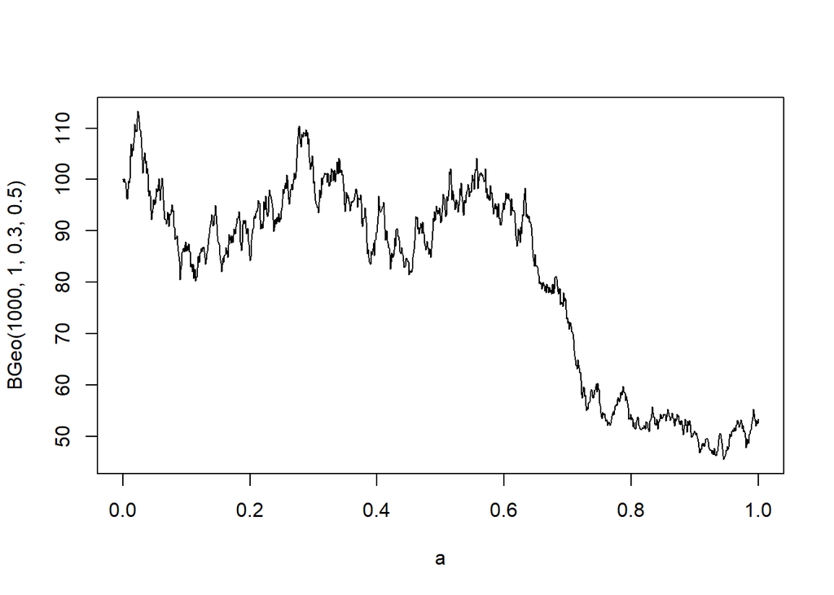

```r
BGeo <- function(n,TT,a,b,S0=100){
         #Función para generar un proceso Browniano Geométrico
  dt <- TT/n #incremento de los intervalos para cubrir [0,TT]
  S <- S0
  for(i in 2:(n+1)){
    S <- append(S, S[i-1]*exp((a-b^2/2)*dt + b*sqrt(dt)*rnorm(1)))
  }
  return(S)
}
plot(a,BGeo(1000,1,0.3,0.5),type="l")
```

### Puente Browniano

El puente Browniano es un tipo de proceso basado en un proceso del mismo tipo que tiene la siguiente propiedad: Si $\{Z_t\}$ es un proceso Browniano, el proceso condicional ${B_t}|B_1=0$ para $t\in [0,1]$. Esto significa que el proceso tiene valor 0 en los extremos del intervalo $[0,1]$. Tiene aplicación por ejemplo para evaluar derivados financieros.

Se puede ver que $B_t = Z_t-tZ_1$ es un puente browniano, lo que define cómo se puede simular.

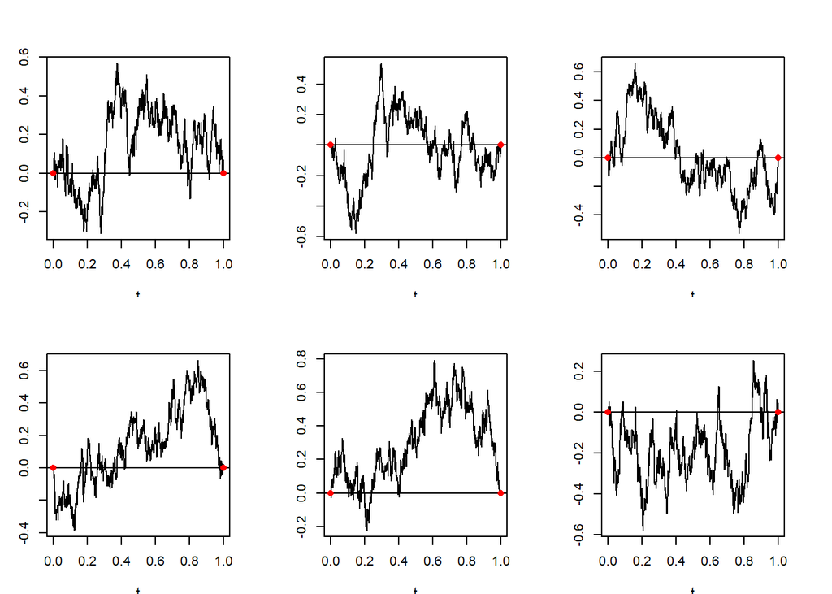

```r
par(pty="s"); par(mfrow=c(2,3));par(mar=c(1,3,1,3))
n <- 1000 #número de puntos en partición
t <- seq(0,1,length=n) #partición del [0,1]
for(i in 1:6){
Z <- c(0,cumsum(rnorm(n-1)))/sqrt(n)
B <- Z-t*Z[n]
plot(t,B,type="l")
abline(h=0);points(c(0,1),c(0,0),col="red",pch=16)}
```

## Procesos Poisson

Hay varias versiones a considerar:

1. Proceso Poisson homogéneo (PPH)
2. Proceso Poisson No homogéneo (PPNH)
3. Proceso Poisson espacial (PPE)

### Proceso Poisson homogéneo

El algoritmo para simular un proceso de Poisson hasta el tiempo $T$ es:

1. Genera tiempos de interarribo exponenciales $\tau_j\sim \exp(\lambda)$
2. Calcula la suma acumulada $S_n =\sum \tau_j$ tal que $S_n <T$
3. Define $N_t=min\{n|S_n>T\}-1$

Ejercicio: simula un PPH con $\lambda=2$ y tiempo de simulación $T=20$

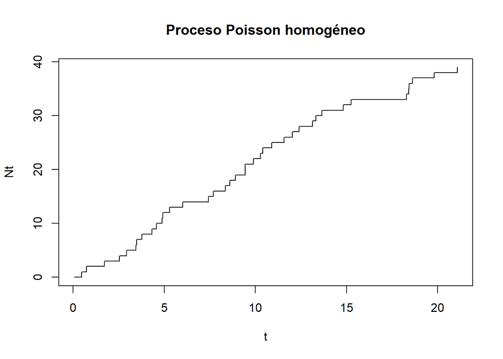

```r
tiempo <- 20
lambda <- 2
tau <- rexp(100,lambda) #genera un número de tiempos de arribo (no previamente determinado)
Tn <- cumsum(tau)  #tiempo acumulado
Nt <- min(which(Tn>tiempo))-1 #Valor del Proceso Poisson
plot(Tn[1:(Nt+1)],0:Nt,type="s", main="Proceso Poisson homogéneo",ylab="Nt",xlab="t")
```

### Proceso Poisson No homogéneo

Para simular un proceso Poisson no homogéneo con intensidad $\lambda(t)$ hasta el tiempo $T$, encontramos una $\lambda_0$ que mayorice a $\lambda(t)$ en el intervalo $[0,T]$: $\lambda(t)\leq \lambda_0 \quad \forall t\in [0,T]$. Entonces simulamos un PPH con tasa $\lambda_0$ y aceptamos un tiempo de arribo en $t$ con probabilidad $p_0=\lambda(t)/\lambda_0$.

El algoritmo es el siguiente: 1. Genera tiempos de interarribo $\tau_j\sim \exp(\lambda_0)$ 2. Calcula la suma acumulada $S_n=\sum \tau_j$ tal que $S_n<T$. 3. Aceptar $S_n$ con probabilidad $\lambda(S_n)/\lambda_0$ creando una nueva sucesión $S^*_n$. 4. Entonces $N^*_T= min\{n|S^*_n>T\}-1$ es el proceso no homogéneo.

Ejercicio: Simula un PPNH con intensidad $\lambda(t)=3t^2$ hasta el tiempo $T=10$

### Proceso Poisson espacial

Un proceso Poisson espacial modela distribución de eventos en el espacio, por ejemplo: árboles de cierta especie en un bosque, distribución de galaxias en el espacio, clústers de cierta enfermedad en un mapa.

Si $p \geq 1$ y $A\subset \mathcal{R}^p$, sea $N_A$ el número de eventos o puntos en el conjunto $A$. $\{N_A|A\subset \mathcal{R}^p\}$ es un proceso Poisson espacial con parámetro $\lambda$ si

1. Para cada conjunto acotado $A$, $N_A \sim \mathcal{P}(\lambda|A|)$ donde $|A|$ es el tamaÃ±o de $A$ (área, volumen, etc.)
2. Si $A\cap B=\emptyset$, entonces $N_A$ es independiente de $B$.
3. Escribir el código para generar un círculo de radio r y centro en c1 y c2.
4. Simula un proceso Poisson espacial en $A=[0,1]^2$, y $\lambda=100$.